# Question 1

To begin, let's generate some random data to work with. Ensure that a common random number seed is used to generate each of the arrays. We will make five arrays, each of length 512, 1024, 2048, 4096, and 8192 containing randomly generated uniformly distributed integers from 1 to 10000. You may use the numpy package for this.

```python
import numpy as np
import time
#use randint to create uniform random array

array1 = np.random.randint(1, 10000, size=512)
print(len(array1))


array2 = np.random.randint(1, 10000, size=1024)
print(len(array2))

array3 = np.random.randint(1, 10000, size=2048)
print(len(array3))


array4 = np.random.randint(1, 10000, size=4096)
print(len(array4))

array5 = np.random.randint(1, 10000, size=8192)
print(len(array5))
```

```
512
1024
2048
4096
8192
```

# Question 2

Sort each of the random number arrays from smallest to largest. You may use any algorithm to sort the data.

```python
#https://numpy.org/devdocs/reference/generated/numpy.sort.html
#sort using algorithm
sort1 = np.sort(array1)
sort2 = np.sort(array2)
sort3 = np.sort(array3)
sort4 = np.sort(array4)
sort5 = np.sort(array5)
```

# Question 3

Execute the base search algorithm (binary search) (from the text and github code) for each of array, noting the execution time for each array. With each execution use the maximum value of the random number array as the number for which you are searching.

```python
#used algorithm from https://github.com/egonSchiele/grokking_algorithms/tree/master/01_introduction_to_algorithms
def binary_search(list, item):
  # low and high keep track of which part of the list you'll search in.
    low = 0
    high = len(list) - 1

  # While you haven't narrowed it down to one element ...
    while low <= high:
    # ... check the middle element
        mid = (low + high) // 2
        guess = list[mid]
    # Found the item.
        if guess == item:
            return mid
    # The guess was too high.
        if guess > item:
            high = mid - 1
    # The guess was too low.
        else:
            low = mid + 1

  # Item doesn't exist
    return None
```

# Question 4

Now we will compare this to a linear search. Use python (perhaps with the Pandas package) to prepare a five-column table containing the following columns with all times in milliseconds:

- length of the random number array
- sort time
- linear search time for the sorted array
- binary search time for the sorted array
- binary search plus sort times

```python
#linearsearch
#source: https://www.geeksforgeeks.org/linear-search/
def linearsearch(array, x):
    for i in range(0, len(array)):
        if array[i] == x:
            return i
    return None
```

```python
a = time.time()
linearsearch(sort1, max(sort1))
b = time.time()
linarr1 = (b - a) * 1000
a = time.time()
linearsearch(sort2, max(sort2))
b = time.time()
linarr2 = (b - a) * 1000
a = time.time()
linearsearch(sort3, max(sort3))
b = time.time()
linarr3 = (b - a) * 1000
a = time.time()
linearsearch(sort4, max(sort4))
b = time.time()
linarr4 = (b - a) * 1000
a = time.time()
linearsearch(sort5, max(sort5))
b = time.time()
linarr5 = (b - a) * 1000
```

```python
a = time.time()
binary_search(sort1, max(sort1))
b = time.time()
binarr1 = (b - a) * 1000

a = time.time()
binary_search(sort2, max(sort2))
b = time.time()
binarr2 = (b - a) * 1000

a = time.time()
binary_search(sort3, max(sort3))
b = time.time()
binarr3 = (b - a) * 1000

a = time.time()
binary_search(sort4, max(sort4))
b = time.time()
binarr4 = (b - a) * 1000

a = time.time()
binary_search(sort5, max(sort5))
b = time.time()
binarr5 = (b - a) * 1000
```

```python
a = time.time()
sort1
b = time.time()
sortarr1 = (b - a) * 1000
a = time.time()
sort2
b = time.time()
sortarr2 = (b - a) * 1000
a = time.time()
sort3
b = time.time()
sortarr3 = (b - a) * 1000
a = time.time()
sort4
b = time.time()
sortarr4 = (b - a) * 1000
a = time.time()
sort5
b = time.time()
sortarr5 = (b - a) * 1000
```

```python
import pandas as pd
algos = [{'length': "Array 1 Length: " + str(len(sort1)), 'sort time':'{} ms'.format(sortarr1) , 'binary search time on sorted': '{} ms'.format(binarr1) , 'linear search time on sorted': '{} ms'.format(linarr1), 'binary search time plus sort': '{} ms'.format(binarr1 + sortarr1)},
         {'length': "Array 1 Length: " + str(len(sort2)), 'sort time':'{} ms'.format(sortarr2) , 'binary search time on sorted': '{} ms'.format(binarr2) , 'linear search time on sorted': '{} ms'.format(linarr2), 'binary search time plus sort': '{} ms'.format(binarr2 + sortarr2)},
         {'length': "Array 1 Length: " + str(len(sort3)), 'sort time':'{} ms'.format(sortarr3) , 'binary search time on sorted': '{} ms'.format(binarr3) , 'linear search time on sorted': '{} ms'.format(linarr3), 'binary search time plus sort': '{} ms'.format(binarr3 + sortarr3)},
         {'length': "Array 1 Length: " + str(len(sort4)), 'sort time':'{} ms'.format(sortarr4) , 'binary search time on sorted': '{} ms'.format(binarr4) , 'linear search time on sorted': '{} ms'.format(linarr4), 'binary search time plus sort': '{} ms'.format(binarr4 + sortarr4)},
         {'length': "Array 1 Length: " + str(len(sort5)), 'sort time':'{} ms'.format(sortarr5) , 'binary search time on sorted': '{} ms'.format(binarr5) , 'linear search time on sorted': '{} ms'.format(linarr5), 'binary search time plus sort': '{} ms'.format(binarr5 + sortarr5)}]
algosdf = pd.DataFrame(algos)
algosdf
```

[output not shown]

# Question 5

Use python matplotlib or Seaborn to generate a plot with the size of the random number array on the horizontal axis and with execution time in milliseconds on the vertical axis. The plot should show execution time against array size for linear and binary search algorithms alone. Discuss the results.

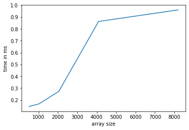

```python
#Binary Search Plot alone
import matplotlib.pyplot as plt
plt.plot([len(array1), len(array2), len(array3), len(array4), len(array5)], [binarr1, binarr2, binarr3, binarr4, binarr5])
plt.xlabel('array size')
plt.ylabel('time in ms')
```

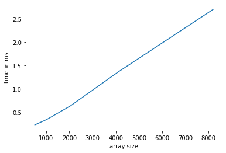

```python
#linear search plot
plt.plot([len(array1), len(array2), len(array3), len(array4), len(array5)], [linarr1, linarr2, linarr3, linarr4, linarr5])
plt.xlabel('array size')
plt.ylabel('time in ms')
```

As the graphs show they are binary search is faster, and flattens out like log(n). With Linear search it takes on a linear plot as can be inferred by the name. As the array size increases the run time increases in linear search.

# Question 6

Use Python matplotlib or Seaborn to generate a measure of the size of the data set on the horizontal axis and with execution time in milliseconds on the vertical axis. The plot should show execution time against array size for each form of the algorithm being tested (last four columns of the table). Discuss the results.

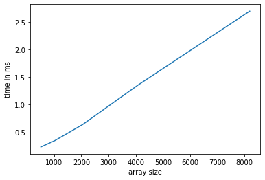

```python
#linsearch plot
plt.plot([len(array1), len(array2), len(array3), len(array4), len(array5)], [linarr1, linarr2, linarr3, linarr4, linarr5])
plt.xlabel('array size')
plt.ylabel('time in ms')
```

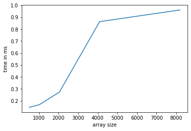

```python
#binarysearch plot
plt.plot([len(array1), len(array2), len(array3), len(array4), len(array5)], [binarr1, binarr2, binarr3, binarr4, binarr5])
plt.xlabel('array size')
plt.ylabel('time in ms')
```

[output not shown]

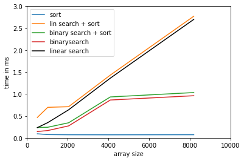

```python
#selection sort + binary search + linear search cominined


plt.xlabel('array size')
plt.ylabel('time in ms')

plt.plot([len(array1), len(array2), len(array3), len(array4), len(array5)], [sortarr1, sortarr2, sortarr3, sortarr4, sortarr5])
plt.plot([len(array1), len(array2), len(array3), len(array4), len(array5)], [linarr1 + linarr1, linarr2 + linarr2, linarr3 + sortarr3, linarr4 + sortarr4, linarr5 + sortarr5])
plt.plot([len(array1), len(array2), len(array3), len(array4), len(array5)], [binarr1 + sortarr1, binarr2 + sortarr2, binarr3 + sortarr3, binarr4 + sortarr4, binarr5 + sortarr5])
plt.plot([len(array1), len(array2), len(array3), len(array4), len(array5)], [binarr1, binarr2, binarr3, binarr4, binarr5])
plt.plot([len(array1), len(array2), len(array3), len(array4), len(array5)], [linarr1, linarr2, linarr3, linarr4, linarr5], color = 'k')
plt.legend(['sort','lin search + sort' , 'binary search + sort', 'binarysearch', 'linear search'])
plt.axis([0, 10000, 0, 3])
```

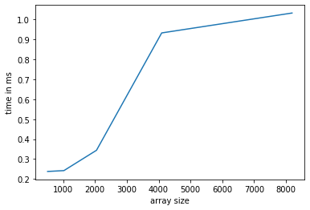

```python
#binary search + sort
plt.xlabel('array size')
plt.ylabel('time in ms')

plt.plot([len(array1), len(array2), len(array3), len(array4), len(array5)], [binarr1 + sortarr1, binarr2 + sortarr2, binarr3 + sortarr3, binarr4 + sortarr4, binarr5 + sortarr5])
```

# Summary

Prepare an executive summary of your results, referring to the table and figures you have generated. Explain how your results relate to big O notation. Describe your results in language that management can understand. This summary should be included as text paragraphs in the Jupyter notebook. Explain how the algorithm works and why it is a useful to data engineers.

Program code should conform to best practices in software development, as described in the coding/software development textbook used in the course.

Set up a personal computer-based Git repository (or private repository on Github) for your work with algorithms this term. Beginning with this week's mini programming assignment, utilize Git as you work on software development.

# Answer

The results are related to big O notation as logarithm usually increases slowly as seen in binary search plot so it is correct like I guessed. Linear is just like how I would have predicted, as well in binary search being faster than linear time. What is ironic it took me a couple of cell runs to come up with the correct log plot.

These algorithms are useful for data engineers, as it is important to have fast algorithms since there can so much data to sort through, or search through. These algorithms make it easier to find a specific occurrence in the volume of data we now have.